# Principal component analysis

Vishesh Kakarala

March 10, 2016

```r
library('base')
library('dplyr')
library('eeptools')
library('taRifx')
library('caret')
library('gbm')
```

Loading the data and viewing the structure of the data loaded

```r
rollingsales_manhattan <- read.csv("~/assignment 3/rollingsales_manhattan_csv.csv", header=TRUE, skip = 4, colClasses = c("NEIGHBORHOOD" = "character", "ADDRESS" = "character","APARTMENT.NUMBER" = "character","LAND.SQUARE.FEET" = "character","GROSS.SQUARE.FEET" = "character","TAX.CLASS.AT.TIME.OF.SALE" = "factor","SALE.PRICE" = "character"))

str(rollingsales_manhattan)
```

```
## 'data.frame':    23757 obs. of  21 variables:
##  $ BOROUGH                       : int  1 1 1 1 1 1 1 1 1 1 ...
##  $ NEIGHBORHOOD                  : chr  "ALPHABET CITY            " "ALPHABET CITY            " "ALPHABET CITY            " "ALPHABET CITY            " ...
##  $ BUILDING.CLASS.CATEGORY       : Factor w/ 43 levels "01  ONE FAMILY DWELLINGS                    ",..: 1 3 3 4 5 5 5 5 5 5 ...
##  $ TAX.CLASS.AT.PRESENT          : Factor w/ 9 levels "  ","1","1A",..: 2 2 2 4 7 7 5 5 5 5 ...
##  $ BLOCK                         : int  400 376 377 399 373 373 377 377 379 387 ...
##  $ LOT                           : int  19 24 66 1101 16 17 2 2 37 119 ...
##  $ EASE.MENT                     : logi  NA NA NA NA NA NA ...
##  $ BUILDING.CLASS.AT.PRESENT     : Factor w/ 130 levels "  ","A1","A4",..: 3 11 11 97 12 12 18 18 18 18 ...
##  $ ADDRESS                       : chr  "526 EAST 5TH STREET                      " "264 EAST 7TH STREET                      " "243 EAST 7TH   STREET                    " "238 EAST 4TH   STREET                    " ...
##  $ APARTMENT.NUMBER              : chr  "            " "            " "            " "-           " ...
##  $ ZIP.CODE                      : int  10009 10009 10009 10009 10009 10009 10009 10009 10009 10009 ...
##  $ RESIDENTIAL.UNITS             : int  1 3 3 1 10 10 22 22 20 22 ...
##  $ COMMERCIAL.UNITS              : int  0 0 0 0 0 0 3 3 2 2 ...
##  $ TOTAL.UNITS                   : int  1 3 3 1 10 10 25 25 22 24 ...
##  $ LAND.SQUARE.FEET              : chr  "1,883" "2,059" "2,381" "0" ...
##  $ GROSS.SQUARE.FEET             : chr  "5,200" "3,696" "3,084" "0" ...
##  $ YEAR.BUILT                    : int  1900 1900 1899 1955 1899 1900 1900 1900 1930 1920 ...
##  $ TAX.CLASS.AT.TIME.OF.SALE     : Factor w/ 3 levels "1","2","4": 1 1 1 1 2 2 2 2 2 2 ...
##  $ BUILDING.CLASS.AT.TIME.OF.SALE: Factor w/ 128 levels "A1","A4","A5",..: 2 10 10 95 11 11 17 17 17 17 ...
##  $ SALE.PRICE                    : chr  "6,500,000" "3,775,000" "2,900,000" "6,995,000" ...
##  $ SALE.DATE                     : Factor w/ 340 levels "1/1/2016","1/11/2016",..: 140 39 237 228 64 64 312 312 133 111 ...
```

# question 1

## Q1 - a : Data Cleaning

```r
#change sale date to date format
rollingsales_manhattan$SALE.DATE <- as.Date(rollingsales_manhattan$SALE.DATE, format = "%m/%d/%Y")


#change sale price to number format
rollingsales_manhattan$SALE.PRICE <- gsub(",","",rollingsales_manhattan$SALE.PRICE)
rollingsales_manhattan$SALE.PRICE <- as.numeric(rollingsales_manhattan$SALE.PRICE)

#change land square feet to number format
rollingsales_manhattan$LAND.SQUARE.FEET <- gsub(",","",rollingsales_manhattan$LAND.SQUARE.FEET)
rollingsales_manhattan$LAND.SQUARE.FEET <- as.numeric(rollingsales_manhattan$LAND.SQUARE.FEET)

#change gross square feet to number format
rollingsales_manhattan$GROSS.SQUARE.FEET <- gsub(",","",rollingsales_manhattan$GROSS.SQUARE.FEET)
rollingsales_manhattan$GROSS.SQUARE.FEET <- as.numeric(rollingsales_manhattan$GROSS.SQUARE.FEET)

#change neighbourhood to factor

rollingsales_manhattan <- rollingsales_manhattan[-which(rollingsales_manhattan$NEIGHBORHOOD == "MANHATTAN-UNKNOWN        "),]
rollingsales_manhattan$NEIGHBORHOOD <- as.factor(rollingsales_manhattan$NEIGHBORHOOD)




# Since we are using only data from the borough of manhattan we can remove the borough column from the data
rollingsales_manhattan <- rollingsales_manhattan[,-1]

# There are no values in Ease.Ment we can remove that column
summary(rollingsales_manhattan$EASE.MENT)
```

```
##    Mode    NA's
## logical   23756
```

```r
rollingsales_manhattan <- rollingsales_manhattan[,-6]
```

Now we can review the structure again to check if all the desired changes have been made

```r
str(rollingsales_manhattan)
```

```
## 'data.frame':    23756 obs. of  19 variables:
##  $ NEIGHBORHOOD                  : Factor w/ 38 levels "ALPHABET CITY            ",..: 1 1 1 1 1 1 1 1 1 1 ...
##  $ BUILDING.CLASS.CATEGORY       : Factor w/ 43 levels "01  ONE FAMILY DWELLINGS                    ",..: 1 3 3 4 5 5 5 5 5 5 ...
##  $ TAX.CLASS.AT.PRESENT          : Factor w/ 9 levels "  ","1","1A",..: 2 2 2 4 7 7 5 5 5 5 ...
##  $ BLOCK                         : int  400 376 377 399 373 373 377 377 379 387 ...
##  $ LOT                           : int  19 24 66 1101 16 17 2 2 37 119 ...
##  $ BUILDING.CLASS.AT.PRESENT     : Factor w/ 130 levels "  ","A1","A4",..: 3 11 11 97 12 12 18 18 18 18 ...
##  $ ADDRESS                       : chr  "526 EAST 5TH STREET                      " "264 EAST 7TH STREET                      " "243 EAST 7TH   STREET                    " "238 EAST 4TH   STREET                    " ...
##  $ APARTMENT.NUMBER              : chr  "            " "            " "            " "-           " ...
##  $ ZIP.CODE                      : int  10009 10009 10009 10009 10009 10009 10009 10009 10009 10009 ...
##  $ RESIDENTIAL.UNITS             : int  1 3 3 1 10 10 22 22 20 22 ...
##  $ COMMERCIAL.UNITS              : int  0 0 0 0 0 0 3 3 2 2 ...
##  $ TOTAL.UNITS                   : int  1 3 3 1 10 10 25 25 22 24 ...
##  $ LAND.SQUARE.FEET              : num  1883 2059 2381 0 2204 ...
##  $ GROSS.SQUARE.FEET             : num  5200 3696 3084 0 8625 ...
##  $ YEAR.BUILT                    : int  1900 1900 1899 1955 1899 1900 1900 1900 1930 1920 ...
##  $ TAX.CLASS.AT.TIME.OF.SALE     : Factor w/ 3 levels "1","2","4": 1 1 1 1 2 2 2 2 2 2 ...
##  $ BUILDING.CLASS.AT.TIME.OF.SALE: Factor w/ 128 levels "A1","A4","A5",..: 2 10 10 95 11 11 17 17 17 17 ...
##  $ SALE.PRICE                    : num  6500000 3775000 2900000 6995000 20000000 ...
##  $ SALE.DATE                     : Date, format: "2015-03-18" "2015-10-22" ...
```

Now we can replace NULL values with NA for statistical analysis

```r
# Replacing blank cells in Apartment number with NA values
rollingsales_manhattan$APARTMENT.NUMBER <- data.frame(gsub("            ",NA,rollingsales_manhattan$APARTMENT.NUMBER, fixed = TRUE))
colnames(rollingsales_manhattan[,8]) <- "APARTMENT.NUMBER"
rollingsales_manhattan$APARTMENT.NUMBER <- as.character(rollingsales_manhattan$APARTMENT.NUMBER)

#Replcaing Land square feet missing values with NA
rollingsales_manhattan$LAND.SQUARE.FEET[rollingsales_manhattan$LAND.SQUARE.FEET == 0] <-NA
#Replcaing gross square feet missing values with NA
rollingsales_manhattan$GROSS.SQUARE.FEET[rollingsales_manhattan$GROSS.SQUARE.FEET == 0] <-NA
#Replacing Year built missing values with NA
rollingsales_manhattan$YEAR.BUILT[rollingsales_manhattan$YEAR.BUILT == 0] <- NA

#We replace total units with 0 value as NA and only replace those values in residential and commercial units corresponding to NA total unit values

rollingsales_manhattan$RESIDENTIAL.UNITS[rollingsales_manhattan$TOTAL.UNITS == 0] <- NA

rollingsales_manhattan$COMMERCIAL.UNITS[rollingsales_manhattan$TOTAL.UNITS == 0] <- NA

rollingsales_manhattan$TOTAL.UNITS[rollingsales_manhattan$TOTAL.UNITS == 0] <- NA
```

Checking for outliers in sales price

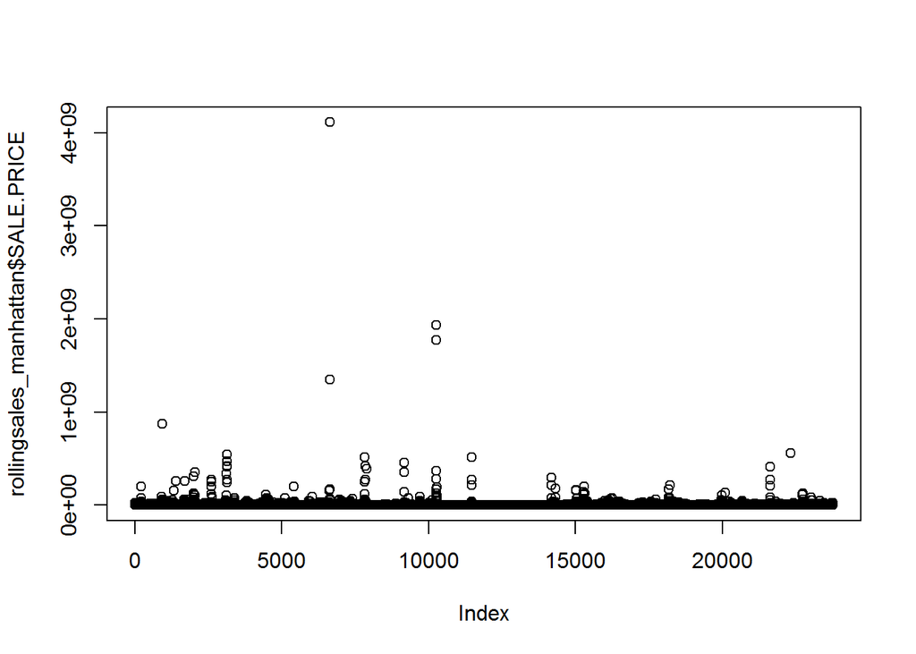

```r
plot(rollingsales_manhattan$SALE.PRICE)
```

```r
#there are very few outliers in the sales price data
```

checking for outliers in land square feet

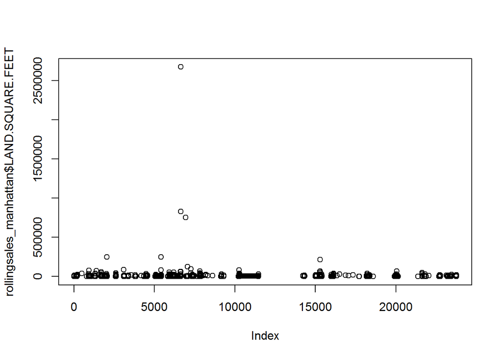

```r
plot(rollingsales_manhattan$LAND.SQUARE.FEET)
```

checking for outliers in gross square feet

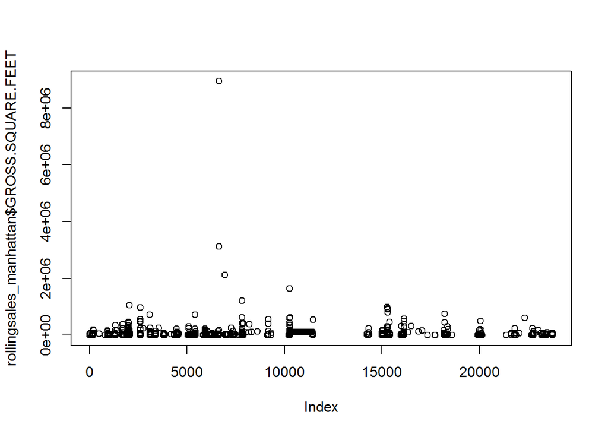

```r
plot(rollingsales_manhattan$GROSS.SQUARE.FEET)
```

we check for the amount of information availble in each column

```r
na.count <- data.frame(c(1:19))
colnames(na.count) <- "column_name"
for(i in 1:19)
{
  na.count$column_name[i] <- colnames(rollingsales_manhattan)[i]
  na.count$count_of_NA[i] <- sum(is.na(rollingsales_manhattan[,i]))
  na.count$pct_of_missing_values[i] <- ((na.count$count_of_NA[i])/23757)*100
}
```